# R markdown basics

Yuanyuan Li

# Introduction

## Create a R markdown file

1. Make sure you already have *rmarkdown* package (check discussion1.pdf for installing it).
2. In RStudio, click the green "+" in the top left> R markdown > write a title and choose output file format > OK
3. Type text in the white space for your report, and only write R code in the grey R chunck, which can be created by click Insert>R or type `` ```{r} `` at the begining and `` ``` `` at the end.

# Links

This is a link for introducing R Markdown Basics: https://rmarkdown.rstudio.com/authoring_basics.html

A R Markdown Cookbook: https://bookdown.org/yihui/rmarkdown-cookbook/r-code.html

# R Code Chunks

**Recommend**: If you want to hide the R code chunk, and only show the results, you can use `echo = FALSE` parameter in the R code chunk:

```
##      speed           dist
##  Min.   : 4.0   Min.   :  2.00
##  1st Qu.:12.0   1st Qu.: 26.00
##  Median :15.0   Median : 36.00
##  Mean   :15.4   Mean   : 42.98
##  3rd Qu.:19.0   3rd Qu.: 56.00
##  Max.   :25.0   Max.   :120.00
```

# Inline R code

There were 50 cars studied.

# Size of plots/images

## 1. Set the size of plots globally

Copy the R chunk below and paste at the begining of your RMD file, use `` ```{r, include=FALSE}``` `` to hide this chunk:

```r
knitr::opts_chunk$set(fig.width=4, fig.height=4)
```

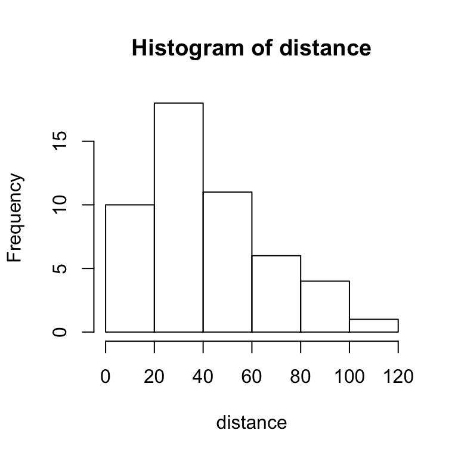

```r
hist(cars$dist,main="Histogram of distance",xlab="distance")
```

## 2. Set the size of plot for one chunk

We can set the chunk options for each chunk too. Use `{r, fig.height = 3, fig.width = 5}` as in below chunk:

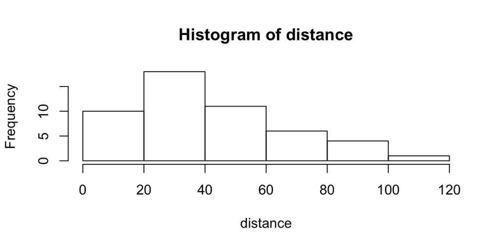

```r
hist(cars$dist,main="Histogram of distance",xlab="distance")
```

# Create tables

Use `knitr::kable` function on an R object, which is typically a matrix or data frame. Type "?kable" in R console to get its help document.

```r
mydata=head(mtcars)
knitr::kable(mydata)
```

|  | mpg | cyl | disp | hp | drat | wt | qsec | vs | am | gear | carb |
| --- | --- | --- | --- | --- | --- | --- | --- | --- | --- | --- | --- |
| Mazda RX4 | 21.0 | 6 | 160 | 110 | 3.90 | 2.620 | 16.46 | 0 | 1 | 4 | 4 |
| Mazda RX4 Wag | 21.0 | 6 | 160 | 110 | 3.90 | 2.875 | 17.02 | 0 | 1 | 4 | 4 |
| Datsun 710 | 22.8 | 4 | 108 | 93 | 3.85 | 2.320 | 18.61 | 1 | 1 | 4 | 1 |
| Hornet 4 Drive | 21.4 | 6 | 258 | 110 | 3.08 | 3.215 | 19.44 | 1 | 0 | 3 | 1 |
| Hornet Sportabout | 18.7 | 8 | 360 | 175 | 3.15 | 3.440 | 17.02 | 0 | 0 | 3 | 2 |
| Valiant | 18.1 | 6 | 225 | 105 | 2.76 | 3.460 | 20.22 | 1 | 0 | 3 | 1 |

# Lists

## Unordered lists

- Item 1
- Item 2
  - Item 2a
  - Item 2b

## Ordered List:

1. Item 1
2. Item 2
3. Item 3
   - Item 3a
   - Item 3b

# LaTeX Equations

$2+4$ $\alpha$

The formula for mean is $\bar{x}=\frac{1}{n}\sum_{i=1}^n x_i$. Display the formula in a new line:
$$\bar{x}=\frac{1}{n}\sum_{i=1}^n x_i$$

# Appendix

```r
summary(cars)
summary(cars)
knitr::opts_chunk$set(fig.width=4, fig.height=4)
hist(cars$dist,main="Histogram of distance",xlab="distance")
hist(cars$dist,main="Histogram of distance",xlab="distance")
mydata=head(mtcars)
knitr::kable(mydata)
```